# EAS648_lab1_mmattwig

Melissa Mattwig

2022-11-01

# Question 1

1. What are the benefits and challenges of an open data science approach? Give an example based on this week’s reading. (1-2 paragraphs)

The benefits of an open data science approach include providing free access to large scales of data. In addition to free access to large amounts of data, this approach extends to open source programs and software to analyze and visualize the data. The article from this week’s reading discussed the amount of data that was collected for the Obama administration during his candidacy for presidency. The amount of social, political, and economic insight that could be gained from this data is hidden and unavailable for analysis. On the other hand, open source data has the challenge of providing false or low-quality data and analysis. Coupled with the fact that there is increasingly large amounts of data created everyday due to the improved capacities of technology, providing falsified data can have huge impacts on decisions made based on that data.

# Visualization of Population in Cuyahoga County, OH (Cleveland)

```r
Ohio <- get_acs(state = "OH", geography = "tract", variables = "B19013_001", geometry = TRUE, cb = FALSE)
racevars <- c(White = "P005003",
              Black = "P005004",
              Asian = "P005006",
              Hispanic = "P004003",
              HouseUnits = "H001001",
              Rent = "H004004" )

Cuyahoga <- get_decennial(geography = "tract", variables = racevars,
                       state = "OH", county = "Cuyahoga County", geometry = TRUE,
                       summary_var = "P001001")
```

```
## Using Census Summary File 1
```

```r
head(Cuyahoga)
```

```
## Simple feature collection with 6 features and 5 fields
## Geometry type: MULTIPOLYGON
## Dimension:     XY
## Bounding box:  xmin: -81.63228 ymin: 41.52807 xmax: -81.62078 ymax: 41.54242
## Geodetic CRS:  NAD83
## # A tibble: 6 x 6
##   GEOID       NAME               varia~1 value summa~2                  geometry
##   <chr>       <chr>              <chr>   <dbl>   <dbl>        <MULTIPOLYGON [°]>
## 1 39035111401 Census Tract 1114~ White       5    1253 (((-81.62634 41.54058, -~
## 2 39035111401 Census Tract 1114~ Black    1219    1253 (((-81.62634 41.54058, -~
## 3 39035111401 Census Tract 1114~ Asian       0    1253 (((-81.62634 41.54058, -~
## 4 39035111401 Census Tract 1114~ Hispan~    16    1253 (((-81.62634 41.54058, -~
## 5 39035111401 Census Tract 1114~ HouseU~   856    1253 (((-81.62634 41.54058, -~
## 6 39035111401 Census Tract 1114~ Rent      364    1253 (((-81.62634 41.54058, -~
## # ... with abbreviated variable names 1: variable, 2: summary_value
```

Here, we are transforming the coordinate reference system to better match Northeast Ohio.

```r
Cuyahoga <- st_transform(Cuyahoga, crs = 32122)
Cuyahoga <- Cuyahoga |> spread(variable, value) |> rename("Pop2010" = "summary_value")
head(Cuyahoga)
```

```
## Simple feature collection with 6 features and 9 fields
## Geometry type: MULTIPOLYGON
## Dimension:     XY
## Bounding box:  xmin: 670797.6 ymin: 202844 xmax: 673367.3 ymax: 208668
## Projected CRS: NAD83 / Ohio North
## # A tibble: 6 x 10
##   GEOID      NAME  Pop2010                  geometry Asian Black Hispa~1 House~2
##   <chr>      <chr>   <dbl>        <MULTIPOLYGON [m]> <dbl> <dbl>   <dbl>   <dbl>
## 1 390351114~ Cens~    1253 (((672898.7 208459.3, 67~     0  1219      16     856
## 2 390351115~ Cens~    1179 (((671624.1 206315.4, 67~     4   725      80     839
## 3 390351116~ Cens~    1130 (((671814 206073.6, 6717~     0   850      64     782
## 4 390351117~ Cens~    1404 (((672017.4 206104.1, 67~     2  1196      56     937
## 5 390351123~ Cens~    1427 (((671616.2 204622, 6716~     1  1275      23     696
## 6 390351135~ Cens~    1221 (((672874.3 202849.4, 67~     0  1184       3     712
## # ... with 2 more variables: Rent <dbl>, White <dbl>, and abbreviated variable
## #   names 1: Hispanic, 2: HouseUnits
```

Visualization of racial data in Cleveland

The first visual is just a base map of Cuyahoga county using `ggplot`.

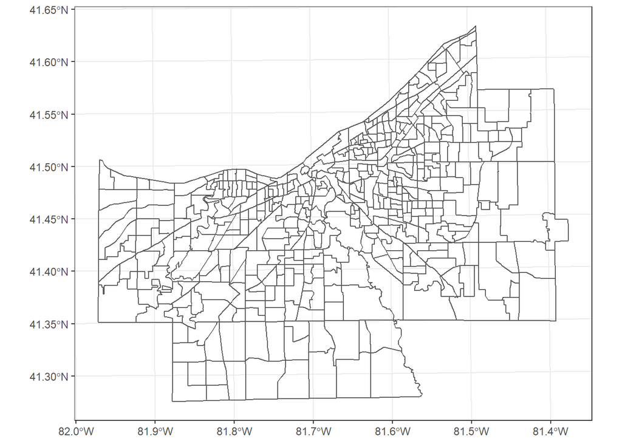

These are the same plots, but adding onto ggplot by adding a color ramp

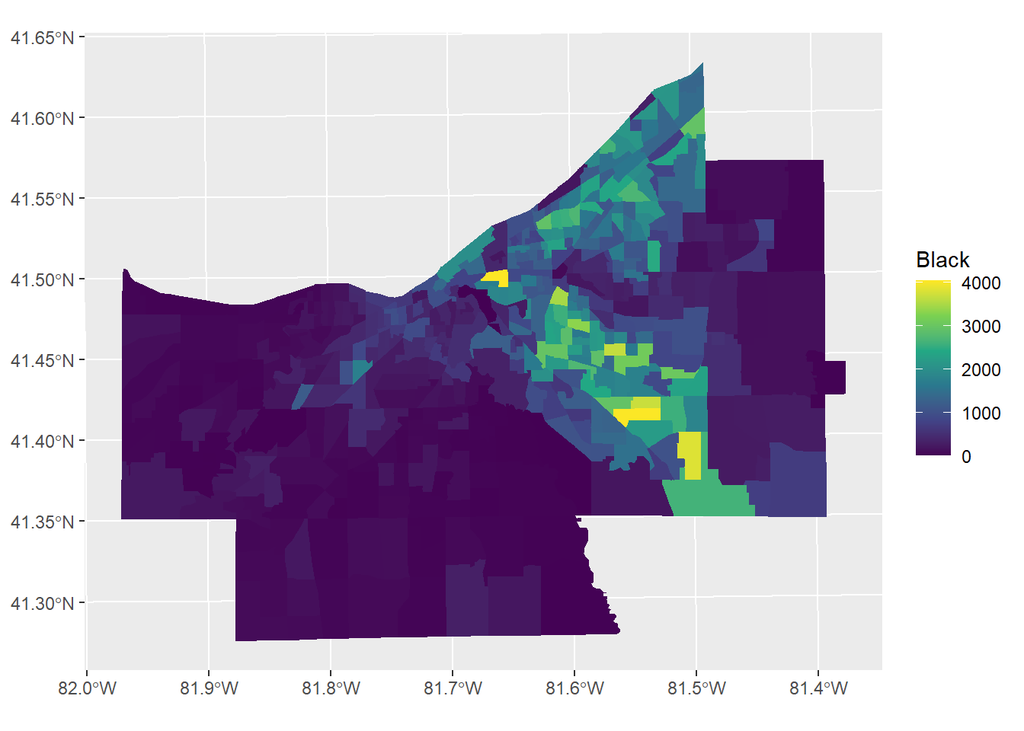

```r
Cuyahoga %>%
  ggplot(aes(fill = Black)) +
  geom_sf(color = NA) +
  coord_sf(crs = 32122) +
  scale_fill_viridis_c(option = "viridis")
```

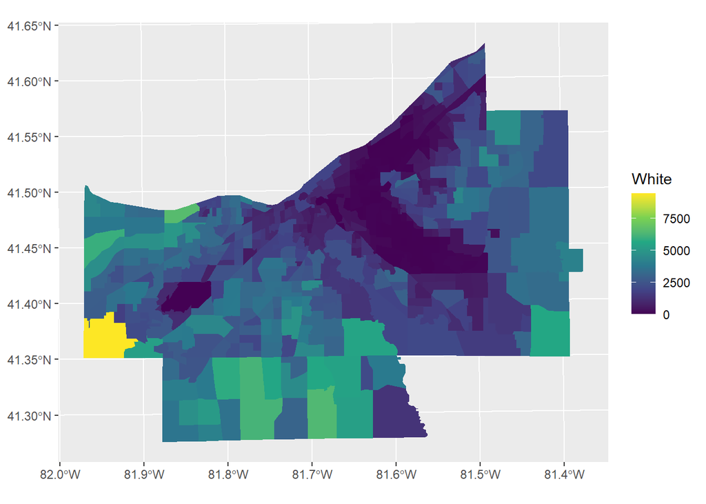

```r
Cuyahoga %>%
  ggplot(aes(fill = White)) +
  geom_sf(color = NA) +
  coord_sf(crs = 32122) +
  scale_fill_viridis_c(option = "viridis")
```

Visualization of Cleveland population using the package `tmaps`

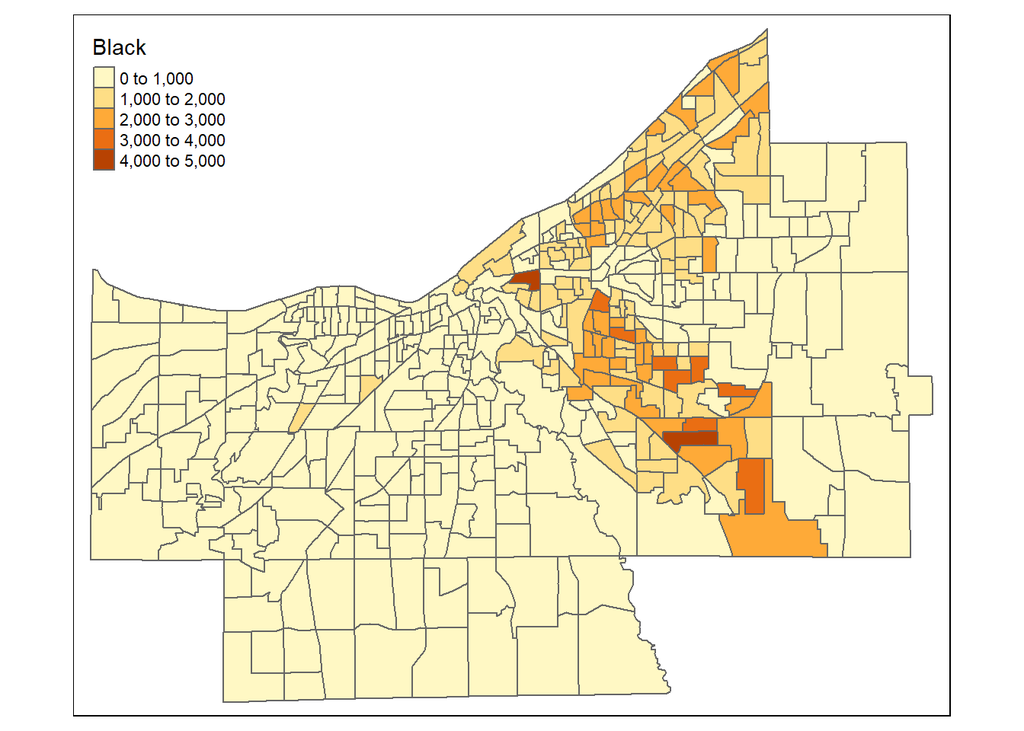

```r
Cuyahoga <- Cuyahoga[1:446,]
tm_shape(Cuyahoga) +
  tm_polygons("Black")
```

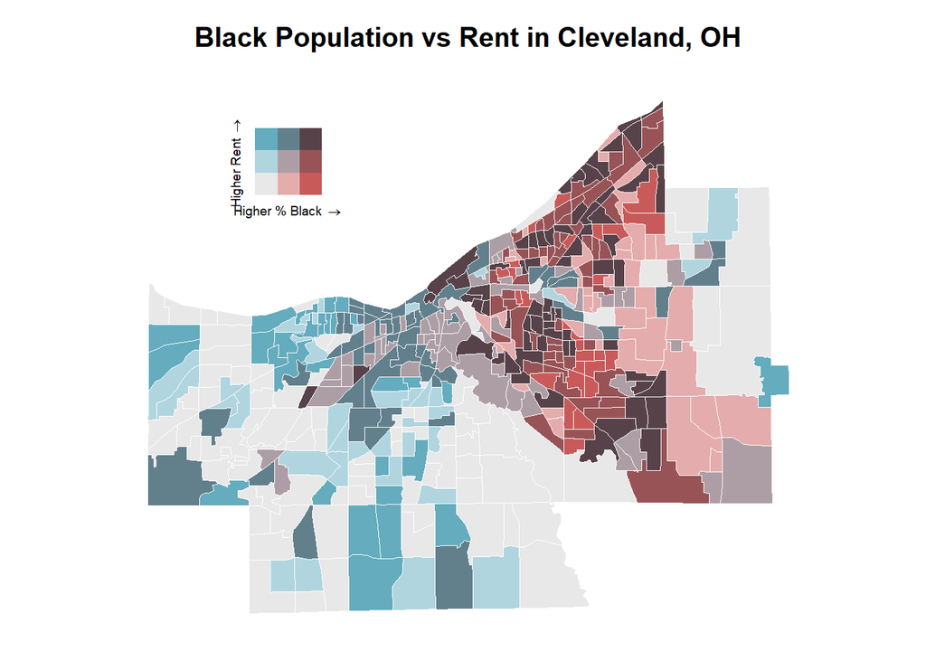

```r
data <- bi_class(Cuyahoga, x = Black, y = Rent, style = "quantile", dim = 3)
map <- ggplot() +
  geom_sf(data = data, mapping = aes(fill = bi_class), color = "white", size = 0.1, show.legend = FALSE) +
  bi_scale_fill(pal = "GrPink", dim = 3) +
  ggtitle("Black Population vs Rent in Cleveland, OH") +
  bi_theme() + theme(plot.title = element_text(size=15))


legend <- bi_legend(pal = "GrPink",
                    dim = 3,
                    xlab = "Higher % Black ",
                    ylab = "Higher Rent ",
                    size = 7)

finalPlot <- ggdraw() +
  draw_plot(map, 0, 0, 1, 1) +
  draw_plot(legend, 0.2, .65, 0.2, 0.2)

finalPlot
```